# IODS course project

### Standardized

Let’s star with the summary of our new, tsandardized version of our old dataset. As we can see, the numbers look very different compared to our first summary: The mean values are set (scaled) to zero (0.0000) and the values are much closer to each other. But the main thing stays the same: The numbers account for the variance in our variables. The numbers can be seen from the summary below:

```r
hdgii_scaled <- scale(hdgii)
summary(hdgii_scaled)
```

```
##     Edu2.FM           Labo.FM           Edu.Exp           Life.Exp
##  Min.   :-2.8189   Min.   :-2.6247   Min.   :-2.7378   Min.   :-2.7188
##  1st Qu.:-0.5233   1st Qu.:-0.5484   1st Qu.:-0.6782   1st Qu.:-0.6425
##  Median : 0.3503   Median : 0.2316   Median : 0.1140   Median : 0.3056
##  Mean   : 0.0000   Mean   : 0.0000   Mean   : 0.0000   Mean   : 0.0000
##  3rd Qu.: 0.5958   3rd Qu.: 0.7350   3rd Qu.: 0.7126   3rd Qu.: 0.6717
##  Max.   : 2.6646   Max.   : 1.6632   Max.   : 2.4730   Max.   : 1.4218
##       GNI             Mat.Mor          Ado.Birth          Parli.F
##  Min.   :-0.9193   Min.   :-0.6992   Min.   :-1.1325   Min.   :-1.8203
##  1st Qu.:-0.7243   1st Qu.:-0.6496   1st Qu.:-0.8394   1st Qu.:-0.7409
##  Median :-0.3013   Median :-0.4726   Median :-0.3298   Median :-0.1403
##  Mean   : 0.0000   Mean   : 0.0000   Mean   : 0.0000   Mean   : 0.0000
##  3rd Qu.: 0.3712   3rd Qu.: 0.1932   3rd Qu.: 0.6030   3rd Qu.: 0.6127
##  Max.   : 5.6890   Max.   : 4.4899   Max.   : 3.8344   Max.   : 3.1850
```

Now when the variables are scaled, we can present them using PCA. First the summary of the model:

```r
pca_scaled <- prcomp(hdgii_scaled)
summary(pca_scaled)
```

```
## Importance of components:
##                           PC1    PC2     PC3     PC4     PC5     PC6
## Standard deviation     2.0708 1.1397 0.87505 0.77886 0.66196 0.53631
## Proportion of Variance 0.5361 0.1624 0.09571 0.07583 0.05477 0.03595
## Cumulative Proportion  0.5361 0.6984 0.79413 0.86996 0.92473 0.96069
##                            PC7     PC8
## Standard deviation     0.45900 0.32224
## Proportion of Variance 0.02634 0.01298
## Cumulative Proportion  0.98702 1.00000
```

As we can see, with standardized data our numbers look very different. The standard deviation values are smaller and, most importantly, our components account for the overall variance in our data: Pc1 is responsible of circa 54 percent, and PC2 circa 16 percent. Together they account for nearly 70 percent of the complete variance. This is how our plot matrix looks like:

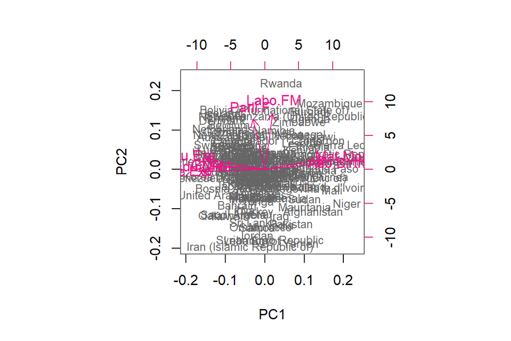

```r
biplot(pca_scaled, choices = 1:2, cex = c(0.8, 1), col = c("grey40", "deeppink2"))
```

## Multiple Correspondence Analysis (MCA) with the tea dataset

Lastly we are going to do some multiple correspondence analysis (MCA) with thea “Tea” dataset. This dataset is form the Factominer package and it consists of 300 observations and 36 variables concerning consumption of tea. Here is the structure of our dataset:

```r
library(FactoMineR)
data("tea")
str(tea)
```

```
## 'data.frame':    300 obs. of  36 variables:
##  $ breakfast       : Factor w/ 2 levels "breakfast","Not.breakfast": 1 1 2 2 1 2 1 2 1 1 ...
##  $ tea.time        : Factor w/ 2 levels "Not.tea time",..: 1 1 2 1 1 1 2 2 2 1 ...
##  $ evening         : Factor w/ 2 levels "evening","Not.evening": 2 2 1 2 1 2 2 1 2 1 ...
##  $ lunch           : Factor w/ 2 levels "lunch","Not.lunch": 2 2 2 2 2 2 2 2 2 2 ...
##  $ dinner          : Factor w/ 2 levels "dinner","Not.dinner": 2 2 1 1 2 1 2 2 2 2 ...
##  $ always          : Factor w/ 2 levels "always","Not.always": 2 2 2 2 1 2 2 2 2 2 ...
##  $ home            : Factor w/ 2 levels "home","Not.home": 1 1 1 1 1 1 1 1 1 1 ...
##  $ work            : Factor w/ 2 levels "Not.work","work": 1 1 2 1 1 1 1 1 1 1 ...
##  $ tearoom         : Factor w/ 2 levels "Not.tearoom",..: 1 1 1 1 1 1 1 1 1 2 ...
##  $ friends         : Factor w/ 2 levels "friends","Not.friends": 2 2 1 2 2 2 1 2 2 2 ...
##  $ resto           : Factor w/ 2 levels "Not.resto","resto": 1 1 2 1 1 1 1 1 1 1 ...
##  $ pub             : Factor w/ 2 levels "Not.pub","pub": 1 1 1 1 1 1 1 1 1 1 ...
##  $ Tea             : Factor w/ 3 levels "black","Earl Grey",..: 1 1 2 2 2 2 2 1 2 1 ...
##  $ How             : Factor w/ 4 levels "alone","lemon",..: 1 3 1 1 1 1 1 3 3 1 ...
```

[output cut: 22 more lines]

```r
dim(tea)
```

```
## [1] 300  36
```

The reason why we choose to use MCA on this data lies in the fact that with the tea data we are dealing with discrete (factor) variables. The main idea and motivation is the same than earlier with PCA: We simply have too many numbers and variables going on! By reducing the dimensions we can again reveal connections and correspondences in our data. Let’s do this, but with fewer variables. We will use variables concerning tea types (“Tea”), the ways how people enjoy their tea (“How”), the price of customers’ tea(s) of choice (“price”), where people buy their tea (“where”), and do people enjoy their tea at luch (“lunch”). Let’s visualize our variables with bar plots so we can see the frequencies and levels of our chosen variables:

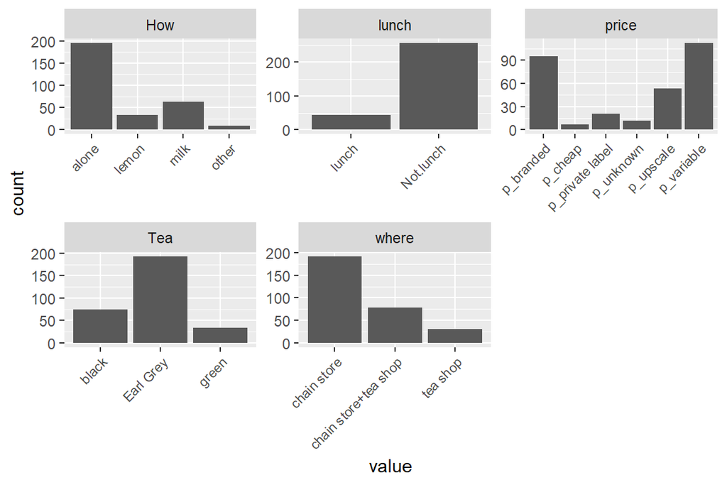

```r
library(tidyr)

keep_columns <- c("Tea", "How", "price", "where", "lunch")

tea_time <- dplyr::select(tea, one_of(keep_columns))

gather(tea_time) %>% ggplot(aes(value)) + facet_wrap("key", scales = "free") + geom_bar() + theme(axis.text.x = element_text(angle = 45, hjust = 1, size = 8))
```

And now it’s time for MCA:

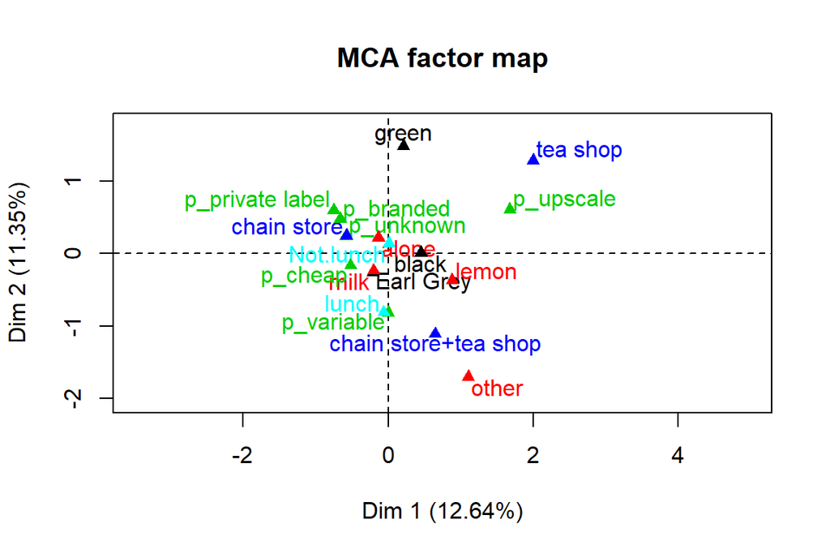

```r
mca <- MCA(tea_time, graph = FALSE)
plot(mca, invisible=c("ind"), habillage = "quali")
```

Our MCA biplot looks quite similar with our ealier PCA plots: We have to dimensions on twho axis’, and we look for the spatial closeness of our observations. Our two dimensions retain circa 24 percentage of the overall variance of the data (12.64% + 11.35%), and the summary below shows that for the full 100 percantage 13 dimensions are needed. The summary also shows the effect of individual observations and individual categories on the dimensions. The table of categorical variables shows the links between variables and dimensions: As can be seen form the plot, the variables “price” (0.696) and “where” (0.720) have the stongest effect on dimension 1 presented on x-axis. Their overall spread on the plot accounts also highly on the variance of dimension 2 (y-axis).

```r
summary(mca)
```

```
##
## Call:
## MCA(X = tea_time, graph = FALSE)
##
##
## Eigenvalues
##                        Dim.1   Dim.2   Dim.3   Dim.4   Dim.5   Dim.6
## Variance               0.329   0.295   0.251   0.233   0.213   0.206
## % of var.             12.640  11.348   9.660   8.943   8.176   7.925
## Cumulative % of var.  12.640  23.989  33.649  42.592  50.768  58.693
##                        Dim.7   Dim.8   Dim.9  Dim.10  Dim.11  Dim.12
## Variance               0.200   0.193   0.166   0.160   0.145   0.128
## % of var.              7.688   7.421   6.402   6.159   5.563   4.911
## Cumulative % of var.  66.381  73.803  80.204  86.364  91.927  96.838
##                       Dim.13
## Variance               0.082
## % of var.              3.162
## Cumulative % of var. 100.000
##
## Individuals (the 10 first)
##                    Dim.1    ctr   cos2    Dim.2    ctr   cos2    Dim.3
## 1               | -0.289  0.085  0.015 |  0.316  0.113  0.018 |  1.130
## 2               | -0.108  0.012  0.006 | -0.238  0.064  0.031 |  0.663
## 3               | -0.316  0.102  0.143 | -0.171  0.033  0.042 | -0.266
## 4               | -0.316  0.102  0.143 | -0.171  0.033  0.042 | -0.266
## 5               | -0.316  0.102  0.143 | -0.171  0.033  0.042 | -0.266
## 6               | -0.579  0.340  0.111 |  0.347  0.136  0.040 | -0.014
## 7               | -0.316  0.102  0.143 | -0.171  0.033  0.042 | -0.266
## 8               | -0.108  0.012  0.006 | -0.238  0.064  0.031 |  0.663
## 9               |  0.672  0.458  0.188 | -0.316  0.113  0.042 |  0.234
## 10              |  0.926  0.869  0.380 | -0.050  0.003  0.001 |  0.485
##                    ctr   cos2
## 1                1.696  0.226 |
## 2                0.583  0.238 |
## 3                0.094  0.101 |
## 4                0.094  0.101 |
## 5                0.094  0.101 |
## 6                0.000  0.000 |
## 7                0.094  0.101 |
## 8                0.583  0.238 |
```

[output cut: 19 more lines]

```
## alone            5.107 | -0.228  2.700  0.097 -5.382 |
## lemon           -2.247 | -0.572  2.864  0.040 -3.476 |
## milk            -2.091 |  0.622  6.478  0.103  5.549 |
## other           -5.166 |  2.688 17.261  0.223  8.174 |
## p_branded        5.559 |  0.028  0.019  0.000  0.327 |
## p_cheap         -0.442 |  1.408  3.683  0.047  3.763 |
## p_private label  2.818 |  0.247  0.339  0.005  1.170 |
##
## Categorical variables (eta2)
##                   Dim.1 Dim.2 Dim.3
## Tea             | 0.084 0.284 0.450 |
## How             | 0.143 0.144 0.368 |
## price           | 0.696 0.410 0.215 |
## where           | 0.720 0.525 0.041 |
## lunch           | 0.001 0.113 0.181 |
```

# RStudio exercise 6: Analysis of longitudinal data

## Let’s download the data!

```r
setwd("C:/Users/lindrha/Documents/GitHub/IODS-project")

library(dplyr)
library(tidyr)
library(ggplot2)
library(GGally)
```

We are going to start our analysis section with introducing our prepared data set. I have already mentioned few thing about our this weeks data sets in the wrangling exercise. If we comparethe set that was created in that former exercise, we see that some of the variables have changed:

```r
BPRSL <- read.csv("bprsl.csv")
str(BPRSL)
```

```
## 'data.frame':    360 obs. of  5 variables:
##  $ treatment: int  1 1 1 1 1 1 1 1 1 1 ...
##  $ subject  : int  1 2 3 4 5 6 7 8 9 10 ...
##  $ weeks    : Factor w/ 9 levels "week0","week1",..: 1 1 1 1 1 1 1 1 1 1 ...
##  $ bprs     : int  42 58 54 55 72 48 71 30 41 57 ...
##  $ week     : int  0 0 0 0 0 0 0 0 0 0 ...
```

So let’s start with few remedial moves. We have to do two things: First we change our “treatment” and “subject” variables back to factors, and then we change our “weeks” variable from factors to characters. After these chanes it’s time to glimpse the data:

```r
BPRSL$treatment <- factor(BPRSL$treatment)
BPRSL$subject <- factor(BPRSL$subject)
BPRSL$weeks <- as.character(BPRSL$weeks)

glimpse(BPRSL)
```

```
## Observations: 360
## Variables: 5
## $ treatment <fct> 1, 1, 1, 1, 1, 1, 1, 1, 1, 1, 1, 1, 1, 1, 1, 1, 1, 1...
## $ subject   <fct> 1, 2, 3, 4, 5, 6, 7, 8, 9, 10, 11, 12, 13, 14, 15, 1...
## $ weeks     <chr> "week0", "week0", "week0", "week0", "week0", "week0"...
## $ bprs      <int> 42, 58, 54, 55, 72, 48, 71, 30, 41, 57, 30, 55, 36, ...
## $ week      <int> 0, 0, 0, 0, 0, 0, 0, 0, 0, 0, 0, 0, 0, 0, 0, 0, 0, 0...
```

And it works!

And now let’s do the same thing with RATS. First the data:

```r
RATSL <- read.csv("rats.csv")
glimpse(RATSL)
```

```
## Observations: 176
## Variables: 5
## $ ID     <int> 1, 2, 3, 4, 5, 6, 7, 8, 9, 10, 11, 12, 13, 14, 15, 16, ...
## $ Group  <int> 1, 1, 1, 1, 1, 1, 1, 1, 2, 2, 2, 2, 3, 3, 3, 3, 1, 1, 1...
## $ WD     <fct> WD1, WD1, WD1, WD1, WD1, WD1, WD1, WD1, WD1, WD1, WD1, ...
## $ Weight <int> 240, 225, 245, 260, 255, 260, 275, 245, 410, 405, 445, ...
## $ Time   <int> 1, 1, 1, 1, 1, 1, 1, 1, 1, 1, 1, 1, 1, 1, 1, 1, 8, 8, 8...
```

And then thea variables “ID” and “Group” into factors, and the factor variable “WD” into character variable:

```r
RATSL$ID <- factor(RATSL$ID)
RATSL$Group <- factor(RATSL$Group)
RATSL$WD <- as.character(RATSL$WD)
glimpse(RATSL)
```

```
## Observations: 176
## Variables: 5
## $ ID     <fct> 1, 2, 3, 4, 5, 6, 7, 8, 9, 10, 11, 12, 13, 14, 15, 16, ...
## $ Group  <fct> 1, 1, 1, 1, 1, 1, 1, 1, 2, 2, 2, 2, 3, 3, 3, 3, 1, 1, 1...
## $ WD     <chr> "WD1", "WD1", "WD1", "WD1", "WD1", "WD1", "WD1", "WD1",...
## $ Weight <int> 240, 225, 245, 260, 255, 260, 275, 245, 410, 405, 445, ...
## $ Time   <int> 1, 1, 1, 1, 1, 1, 1, 1, 1, 1, 1, 1, 1, 1, 1, 1, 8, 8, 8...
```

This works ok.

## Analysis with RATS

Perhaps the best way to start investigating a new data set is to produce it graphically. Sow let’s plot our data! We start with displaying all the individual rats in our data and their respecting weights over time. We do this in three plots so we can also analyse the values and varitions among all of the three groups in our data set. The plots look like this:

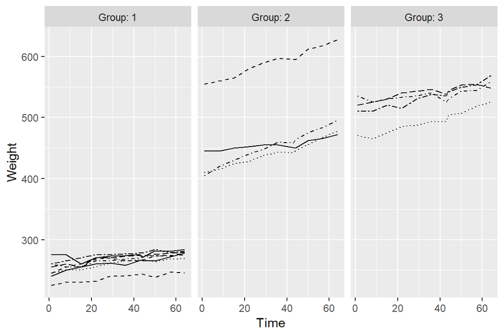

```r
library(dplyr)
library(tidyr)
library(ggplot2)
library(GGally)

ggplot(RATSL, aes(x = Time, y = Weight, linetype = ID)) +
  geom_line() +
  scale_linetype_manual(values = rep(1:10, times=4)) +
  facet_grid(. ~ Group, labeller = label_both) +
  theme(legend.position = "none") +
  scale_y_continuous(limits = c(min(225), max(628)))
```

These three plots show us very conveniently some main characteristic in our data. First of all there is a clear difference between each of our groups: The group number one has significantly lower weight range and less variability than the other groups. In overall the trend is that the average weights rise with the groups. In the second group there seems to be one outlier which is completely in its own class. From the summary below we can see that the individual with the lowest weight in our data has a value of 225.0 (this individual belongs to the first group). Compared to this our highest observed value is as high 628.0. This individual belongs to the secong group and it certainly effects the analysis concerning the whole group.

```r
summary(RATSL$Weight)
```

```
##    Min. 1st Qu.  Median    Mean 3rd Qu.    Max.
##   225.0   267.0   344.5   384.5   511.2   628.0
```

Before we take actions against our outlier, we do some enlightening comparing with our plot above and a new standardized version of it. This helps us to compare the effect of our diets to the starting wights of our individual rats.

```r
RATSLS <- RATSL %>%
  group_by(Time) %>%
  mutate(stdweight = (Weight - mean(Weight))/sd(Weight) ) %>%
  ungroup()

glimpse(RATSLS)
```

```
## Observations: 176
## Variables: 6
## $ ID        <fct> 1, 2, 3, 4, 5, 6, 7, 8, 9, 10, 11, 12, 13, 14, 15, 1...
## $ Group     <fct> 1, 1, 1, 1, 1, 1, 1, 1, 2, 2, 2, 2, 3, 3, 3, 3, 1, 1...
## $ WD        <chr> "WD1", "WD1", "WD1", "WD1", "WD1", "WD1", "WD1", "WD...
## $ Weight    <int> 240, 225, 245, 260, 255, 260, 275, 245, 410, 405, 44...
## $ Time      <int> 1, 1, 1, 1, 1, 1, 1, 1, 1, 1, 1, 1, 1, 1, 1, 1, 8, 8...
## $ stdweight <dbl> -1.0011429, -1.1203857, -0.9613953, -0.8421525, -0.8...
```

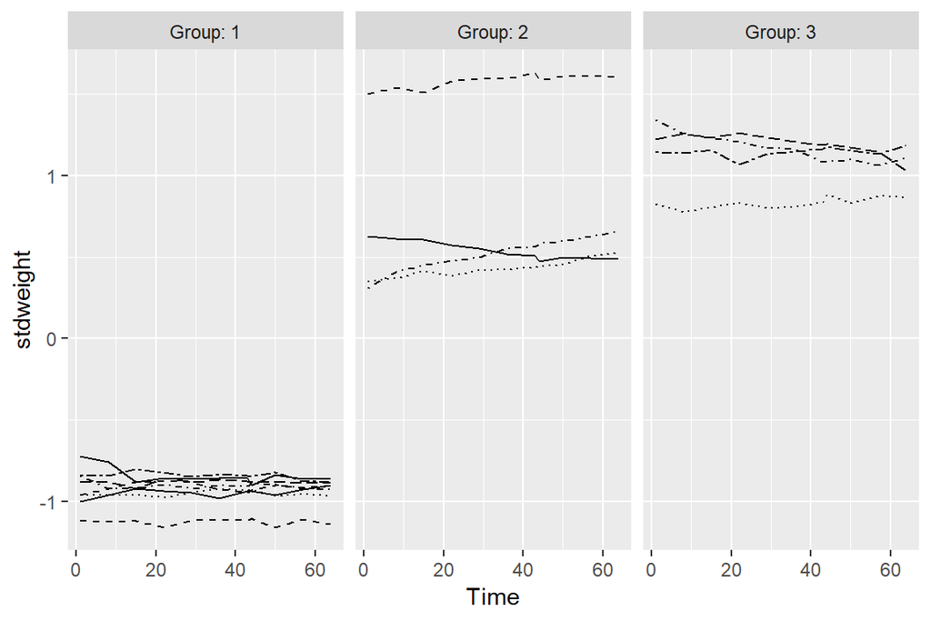

```r
ggplot(RATSLS, aes(x = Time, y = stdweight, linetype = ID)) +
  geom_line() +
  scale_linetype_manual(values = rep(1:10, times=4)) +
  facet_grid(. ~ Group, labeller = label_both) +
  theme(legend.position = "none")
```

These scaled plots tell the same thing and maybe even more clearly: Group three fits completely between the the groups twos heaviest and second heaviest rats. This outlier must effect strongly on the mean of the our second group. The boxplots below shows and graphically displays the ranges and means of our groups. The second groups boxplot clearly looks dirrerent from the other two:

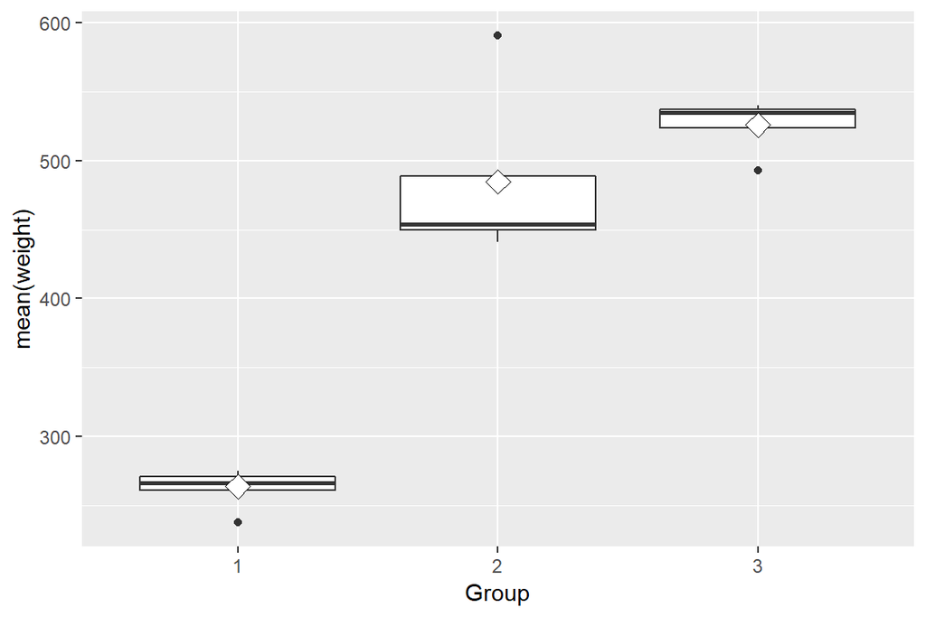

```r
RATSS <- RATSLS %>%
  filter(Time > 0) %>%
  group_by(Group, ID) %>%
  summarise( mean=mean(Weight) ) %>%
  ungroup()


ggplot(RATSS, aes(x = Group, y = mean)) +
  geom_boxplot() +
  stat_summary(fun.y = "mean", geom = "point", shape=23, size=4, fill = "white") +
  scale_y_continuous(name = "mean(weight)")
```

And now let’s get rid of the outlier and see how our boxplots look without it:

```r
RATSSS <- RATSS %>%
  filter(mean < 560)

summary(RATSSS)
```

```
##  Group       ID         mean
##  1:8   1      :1   Min.   :237.6
##  2:3   2      :1   1st Qu.:266.0
##  3:4   3      :1   Median :274.7
##        4      :1   Mean   :370.8
##        5      :1   3rd Qu.:473.9
##        6      :1   Max.   :540.2
##        (Other):9
```

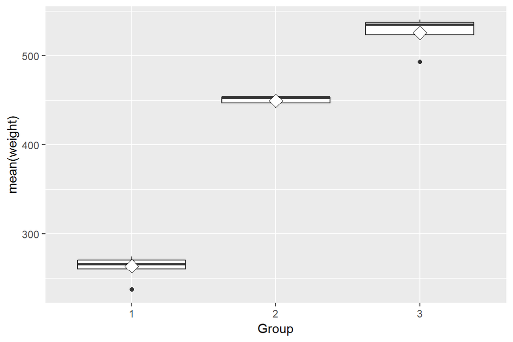

```r
ggplot(RATSSS, aes(x = Group, y = mean)) +
  geom_boxplot() +
  stat_summary(fun.y = "mean", geom = "point", shape=23, size=4, fill = "white") +
  scale_y_continuous(name = "mean(weight)")
```

Now this looks in many ways very different form all the other plots we have seen. There still exists the big difference between the forst group and other other groups. The difference lies in the overall shape of the second groups box. In the previous box the second box, because its huge range, was all over the place. Now its range and overall variation is the smallest of all groups. There is also a radical shift in the groups mean, marked with a white dimond shaped box, which has sunken from a value close to 500 to around 450.